# Derivatives Course

## Join our course to understand derivatives!

| Function | Derivative |
| --- | --- |
| $f(x) = c$ | \(f'(x) = 0\) |
| \(f(x) = x\) | \(f'(x) = 1\) |
| \(f(x) = x^n\) | \(f'(x) = nx^{n-1}\) |
| \(f(x) = e^x\) | \(f'(x) = e^x\) |
| \(f(x) = \ln(x)\) | \(f'(x) = \frac{1}{x}\) |
| \(f(x) = \sin(x)\) | \(f'(x) = \cos(x)\) |
| \(f(x) = \cos(x)\) | \(f'(x) = -\sin(x)\) |
| \(f(x) = \tan(x)\) | \(f'(x) = \sec^2(x)\) |

| Function | Derivative | Name |
| --- | --- | --- |
| $f(x) = c \cdot g(x)$ | $f'(x) = c \cdot g'(x)$ | Constant Multiple Rule |
| $f(x) = g(x) + h(x)$ | $f'(x) = g'(x) + h'(x)$ | Sum Rule |
| $f(x) = g(x) \cdot h(x)$ | $f'(x) = g'(x) \cdot h(x) + g(x) \cdot h'(x)$ | Product Rule |
| $f(x) = \dfrac{g(x)}{h(x)}$ | $f'(x) = \dfrac{g'(x) \cdot h(x) - g(x) \cdot h'(x)}{h(x)^2}$ | Quotient Rule |
| $f(x) = g(h(x))$ | $f'(x) = g'(h(x)) \cdot h'(x)$ | Chain Rule |

### Derivative Exercises

1. **Basic Derivatives:**
   - Calculate the derivative of the following functions:
     - $ f(x) = 2x^3 - 5x^2 + 3x - 7 $
     - $ g(x) = \sin(x) + \cos(x) $
     - $ h(x) = e^x - \ln(x) $
2. **Product and Quotient Rules:**
   - Use the product rule to find the derivative of $ f(x) = (3x^2 + 2x)(x^3 - x + 1) $.
   - Use the quotient rule to find the derivative of $ g(x) = \frac{x^2 + 1}{x^3 - 2x} $.
3. **Chain Rule:**
   - Find the derivative of $ f(x) = \sin(x^2 + 3x) $ using the chain rule.
   - Find the derivative of $ g(x) = e^{x^2 + 1} $ using the chain rule.
4. **Higher-Order Derivatives:**
   - Calculate the second derivative of $ f(x) = x^4 - 3x^3 + 2x^2 - x + 5 $.
   - Calculate the second derivative of $ g(x) = \ln(x^2 + 1) $.

## Derivative Interpretation

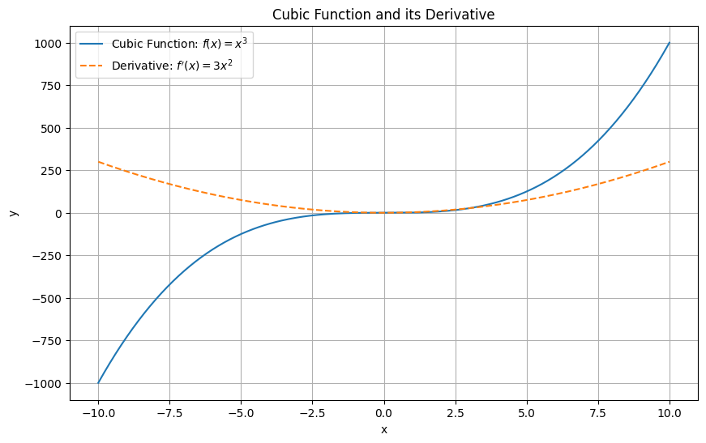

## Demonstration of Derivative Functions

### Derivative of Simple Functions Using Limits

The derivative of a function $ f(x) $ at a point $ x $ is defined as the limit of the average rate of change of the function as the interval around $ x $ approaches zero. The derivative of a function $ f(x) $ at a point $ x $ is denoted as $ f'(x) $ or $ \frac{{df}}{{dx}} $.

The derivative of a function $ f(x) $ at a point $ x $ is defined as: $$ f'(x) = \lim_{{h \to 0}} \frac{{f(x + h) - f(x)}}{h} $$

To understand the concept of derivatives, let's start with some simple functions and calculate their derivatives using the limit definition.

1. **Derivative of $ f(x) = x^2 $**

   The derivative of $ f(x) = x^2 $ using the limit definition is: $$ f'(x) = \lim_{{h \to 0}} \frac{{(x + h)^2 - x^2}}{h} $$ Simplifying the expression inside the limit: $$ f'(x) = \lim_{{h \to 0}} \frac{{x^2 + 2xh + h^2 - x^2}}{h} = \lim_{{h \to 0}} \frac{{2xh + h^2}}{h} = \lim_{{h \to 0}} (2x + h) = 2x $$
2. **Derivative of $ f(x) = x $**

   The derivative of $ f(x) = x $ using the limit definition is: $$ f'(x) = \lim_{{h \to 0}} \frac{{(x + h) - x}}{h} $$ Simplifying the expression inside the limit: $$ f'(x) = \lim_{{h \to 0}} \frac{x + h - x}{h} = \lim_{{h \to 0}} \frac{h}{h} = \lim_{{h \to 0}} 1 = 1 $$
3. **Derivative of $ f(x) = c \cdot g(x) $**

   The derivative of $ f(x) = c \cdot g(x) $ using the limit definition is: $$ f'(x) = \lim_{{h \to 0}} \frac{{c \cdot g(x + h) - c \cdot g(x)}}{h} $$ Factoring out the constant $c$: $$ f'(x) = c \cdot \lim_{{h \to 0}} \frac{{g(x + h) - g(x)}}{h} $$ By definition, this is: $$ f'(x) = c \cdot g'(x) $$